# Visualização em dados para que seja observado se o jogador mudou o resultado da Partida.

Data Gols.

2023-10-09

# Pacotes

```r
# Pacotes
library(readr)
library(ggplot2)
library(dplyr)
library(knitr)
library(png)
library(readr)
library(gridExtra)
library(psych)
library(rstatix)
library(graphics)
library(tidyr)
library(stats)
```

# Introdução.

Recentemente levantou-se a discussão sobre qual a contribuição que o atleta de futebol do Arsenal, Gabriel Martinelli tem de decisão em mudar o resultado de uma partida. Esse diálogo surge em meio a vitória do Arsenal diante do Manchester city. Seria bastante leviano da minha parte ficar de fora e não apresentar os dados amostrais do Gabriel na temporada passada para elucidar de forma coerente e unânime essas provocações.

# Visão Geral do jogador.

Atualmente ele possui 22 anos e tem altura de 1.80cm, nasceu em 18 de junho de 2001. Sua posição é de atacante e tem seu pé preferido à direita. Seus pontos fortes são as bolas longas e tem uma capacidade de armação criando jogadas para o clube inglês. O seu principal ponto fraco são os duelos aéreos. Está no Arsenal desde 01 de julho 2019, no qual foi vendido do Ituano, clube brasileiro de futebol.

# Material e Resultados.

Os dados foram coletados através do banco de dados do sofascore, filtrados e reorganizados por excel e manipulados em Rstudio. Além disso, para ficar familiar ao meu método de visualização de dados, busquei as datas e os clubes com nomenclatura no site futebol.uk. Que tem anos de experiência com Premier League e é extremamente confiável.

Na primeira visualização de dados em que eu apresento são o número de gols marcados pelo atleta na temporada 2022/2023. Na qual marcou 15 gols. Vale ressaltar que o brasileiro marcou mais de um gol contra o Everton na mesma partida! e marcou pelo menos um gol no ponto representado no gráfico. Saiba que, como existe uma temporada regular do campeonato, são 38 rodadas, com jogos fora e em casa, Martinelli ficou de fora apenas 2 onde teve uma lesão no tornozelo.

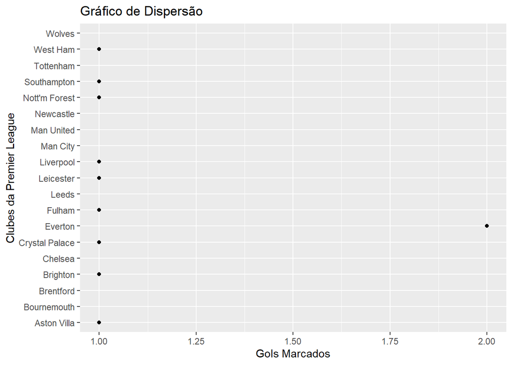

# Análise descritiva dos dados.

Criei uma tabela para observar a quantidade de gols que o Arsenal marcou na temporada 2022/2023. Em que são observados as seguintes variáveis que compõem minha tabela. Observe abaixo.

| Sigla | Descricao |
| --- | --- |
| Opp | Adversarios |
| Média | Gols marcados dividio por confrontos ida e volta |
| DP | Desvio padrão em relação a média |
| Var | a variância amostral mostra quantos ponto distante da média de gols |
| max | maximo de gols |
| min | minimos de gols |

Foi verificada a amplitude amostral dos gols marcados e são eles 5 com 7 grupos. Que possuem a mesma efetividade e ou padrão amostral.

| Opp | media | DP | mediana | var | max | min |
| --- | --- | --- | --- | --- | --- | --- |
| Aston Villa | 3.0 | 1.41 | 3.0 | 2.0 | 4 | 2 |
| Bournemouth | 3.0 | 0.00 | 3.0 | 0.0 | 3 | 3 |
| Brentford | 2.0 | 1.41 | 2.0 | 2.0 | 3 | 1 |
| Brighton | 2.0 | 2.83 | 2.0 | 8.0 | 4 | 0 |
| Chelsea | 2.0 | 1.41 | 2.0 | 2.0 | 3 | 1 |
| Crystal Palace | 3.0 | 1.41 | 3.0 | 2.0 | 4 | 2 |
| Everton | 2.0 | 2.83 | 2.0 | 8.0 | 4 | 0 |
| Fulham | 2.5 | 0.71 | 2.5 | 0.5 | 3 | 2 |
| Leeds | 2.5 | 2.12 | 2.5 | 4.5 | 4 | 1 |
| Leicester | 2.5 | 2.12 | 2.5 | 4.5 | 4 | 1 |
| Liverpool | 2.5 | 0.71 | 2.5 | 0.5 | 3 | 2 |
| Man City | 1.0 | 0.00 | 1.0 | 0.0 | 1 | 1 |
| Man United | 2.0 | 1.41 | 2.0 | 2.0 | 3 | 1 |
| Newcastle | 1.0 | 1.41 | 1.0 | 2.0 | 2 | 0 |
| Nott’m Forest | 2.5 | 3.54 | 2.5 | 12.5 | 5 | 0 |
| Southampton | 2.0 | 1.41 | 2.0 | 2.0 | 3 | 1 |
| Tottenham | 2.5 | 0.71 | 2.5 | 0.5 | 3 | 2 |
| West Ham | 2.5 | 0.71 | 2.5 | 0.5 | 3 | 2 |
| Wolves | 3.5 | 2.12 | 3.5 | 4.5 | 5 | 2 |

# Método box plot

De forma universal o box plot é uma caixa que comprime os dados fazendo deles um resumo dos jogos observados. Neste levantamento podemos informar a quantidade de gols marcados do Time do Arsenal em 38 partidas.

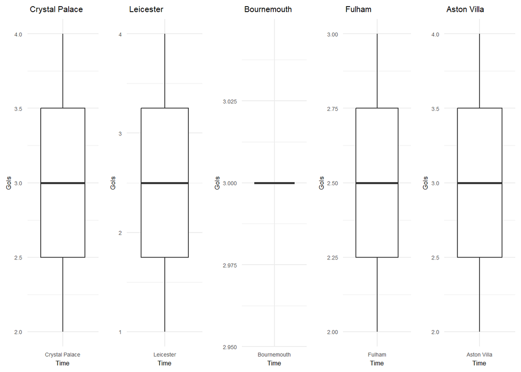

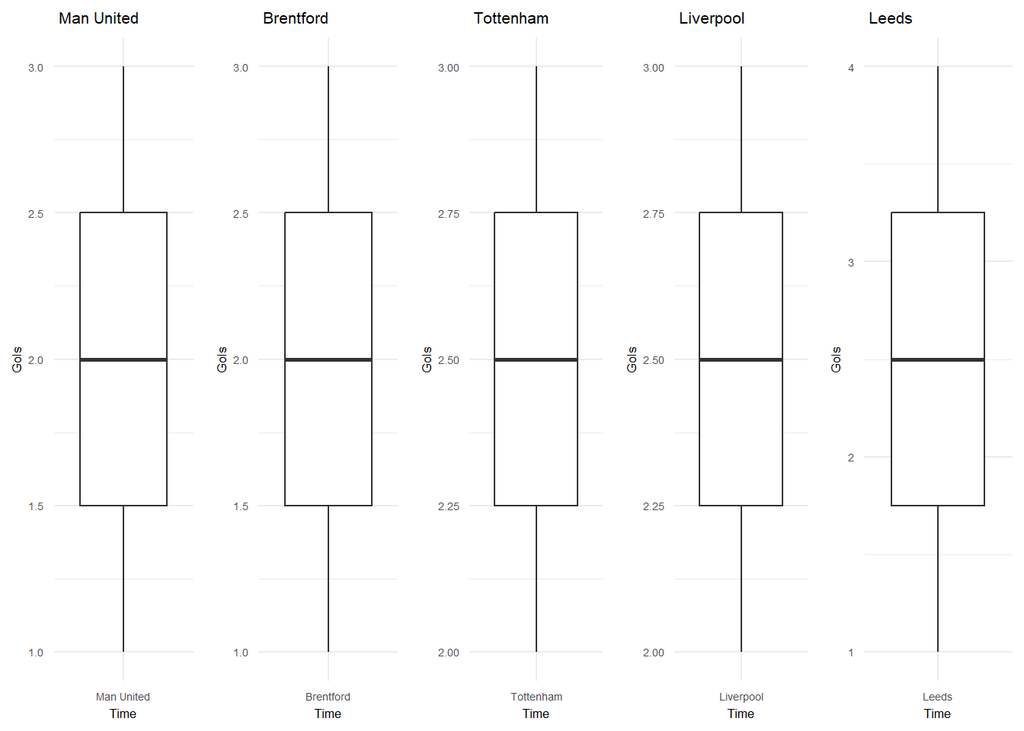

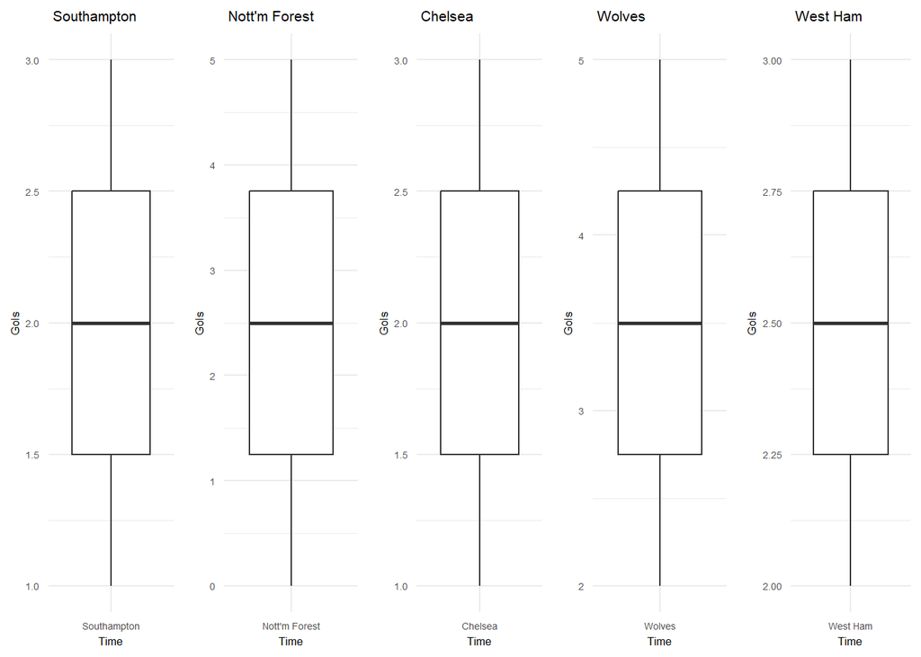

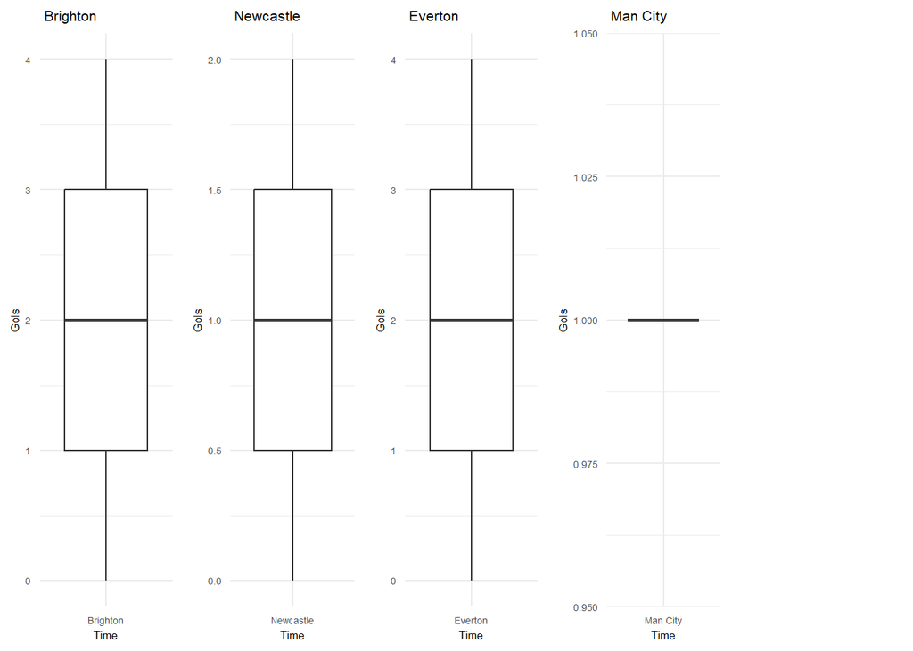

# Partidas que o Martinelli mudou o resultado do jogo.

Critério, caso ele tenha marcado um gol quando o time estiver empatando ou perdendo que leve ao empate é considerado decisivo ou deu a vitória e será nomeado de True. Caso contrário será chamado de False que representa que não foi decisivo ou apenas descontou, reduzindo a vantagem do time adversário. Ah ainda mais um critério que é chamado de expandi, onde o atleta marca e aumenta o placar.

Visualizando a tabela amostral.

| Rodada | Data | Opp | FTG | FTR | Pos. | G | MP | CJ |
| --- | --- | --- | --- | --- | --- | --- | --- | --- |
| 1 | 05/08/2022 | Crystal Palace | 2 | A | PE | 1 | TRUE | desempatou |
| 2 | 13/08/2022 | Leicester | 4 | H | PE | 1 | FALSE | expandiu |
| 5 | 31/08/2022 | Aston Villa | 2 | H | PE | 1 | TRUE | desempatou |
| 10 | 09/10/2022 | Liverpool | 3 | H | PE | 1 | TRUE | desempatou |
| 14 | 30/10/2022 | Nott’m Forest | 5 | H | PE | 1 | TRUE | desempatou |
| 17 | 26/12/2022 | West Ham | 3 | H | PE | 1 | TRUE | desempatou |
| 18 | 31/12/2022 | Brighton | 4 | A | PE | 1 | FALSE | expandiu |
| 24 | 18/02/2023 | Aston Villa | 4 | A | PE | 1 | FALSE | expandiu |
| 25 | 25/02/2023 | Leicester | 1 | A | PE | 1 | TRUE | desempatou |
| 7 | 01/03/2023 | Everton | 4 | H | CA | 2 | FALSE | expandiu |
| 27 | 12/03/2023 | Fulham | 3 | A | PE | 1 | FALSE | expandiu |
| 28 | 19/03/2023 | Crystal Palace | 4 | H | PE | 1 | TRUE | desempatou |
| 30 | 09/04/2023 | Liverpool | 2 | D | PE | 1 | TRUE | desempatou |
| 32 | 21/04/2023 | Southampton | 3 | D | PE | 1 | FALSE | descontou |

# Teoria da Distribuição Binomial

A distribuição binomial é um modelo estatístico que descreve a probabilidade de um evento binário (um evento que pode ocorrer em duas categorias mutuamente exclusivas, como sucesso ou fracasso) em uma série de tentativas independentes e idênticas. Ela é amplamente utilizada em estatística para modelar situações onde estamos interessados em contar o número de sucessos em um número fixo de tentativas.

## Fórmula da Distribuição Binomial

A probabilidade de obter exatamente “k” sucessos em “n” tentativas independentes, com uma probabilidade de sucesso “p” em cada tentativa, pode ser calculada pela seguinte fórmula da distribuição binomial:

$$P(X = k) = \binom{n}{k} \cdot p^k \cdot
(1 - p)^{n - k}$$

Onde:

- $P(X = k)$ é a probabilidade de obter exatamente “k” sucessos.
- $n$ é o número total de tentativas.
- $p$ é a probabilidade de sucesso em cada tentativa.
- $k$ é o número de sucessos que estamos interessados em contar.
- $\binom{n}{k}$ representa o coeficiente binomial, que calcula o número de maneiras de escolher “k” sucessos em “n” tentativas.

## Explicação

- A fórmula da distribuição binomial calcula a probabilidade de exatamente “k” sucessos em “n” tentativas independentes.
- $p^k$ representa a probabilidade de “k” sucessos.
- $(1 - p)^{n - k}$ representa a probabilidade de “n - k” falhas (ou fracassos).
- $\binom{n}{k}$ calcula o número de maneiras diferentes de obter “k” sucessos em “n” tentativas.
- Somando todas as combinações, obtemos a probabilidade total de “k” sucessos em “n” tentativas.

A distribuição binomial é fundamental em estatística e é amplamente aplicável em várias áreas, como biologia, engenharia, economia e muitas outras, para modelar situações de teste de hipóteses, previsões e análise de resultados de experimentos. É uma ferramenta poderosa para compreender e quantificar a probabilidade de eventos binários em experimentos repetíveis.

.

```
##
##  Exact binomial test
##
## data:  x and n
## number of successes = 8, number of trials = 14, p-value = 1
## alternative hypothesis: true probability of success is not equal to 0.5724
## 95 percent confidence interval:
##  0.2886094 0.8233889
## sample estimates:
## probability of success
##              0.5714286
```

# Resultado e Observações.

Número de sucessos observados (x) = 8 Número de tentativas (n) = 14 P-valor = 1 Hipótese alternativa: A verdadeira probabilidade de sucesso não é igual a 0.5724 Intervalo de confiança de 95%: (0.2886094, 0.8233889) Estimativa da probabilidade de sucesso: 0.5714286 O p-valor é igual a 1, o que significa que não há evidências para rejeitar a hipótese nula de que a probabilidade de sucesso é igual a 0.5724. Isso indica que, com base nos dados e no nível de significância escolhido, não podemos concluir que a probabilidade de sucesso é significativamente diferente de 0.5724.

Portanto, o poder de decisão do atleta, com base neste teste, não é considerado significativamente diferente da probabilidade de sucesso de 0.5724.

# Conclusão